# Facebook Data ROI

A lot of original text came from https://www.kaggle.com/chrisbow/an-introduction-to-facebook-ad-analysis-using-r

```python
import pandas as pd
import numpy as np
import matplotlib.pyplot as plt

%matplotlib inline
```

### Load Dataset

#### About Data Columns

1.) ad_id: an unique ID for each ad.  
2.) xyz_campaign_id: an ID associated with each ad campaign of XYZ company.  
3.) fb_campaign_id: an ID associated with how Facebook tracks each campaign.  
4.) age: age of the person to whom the ad is shown.  
5.) gender: gender of the person to whim the add is shown  
6.) interest: a code specifying the category to which the person's interest belongs (interests are as mentioned in the person's Facebook public profile).  
7.) Impressions: the number of times the ad was shown.  
8.) Clicks: number of clicks on for that ad.  
9.) Spent: Amount paid by company xyz to Facebook, to show that ad.  
10.) Total conversion: Total number of people who enquired about the product after seeing the ad.  
11.) Approved conversion: Total number of people who bought the product after seeing the ad.

### Load the Data

```python
url = 'https://raw.githubusercontent.com/mGalarnyk/Python_Tutorials/master/Kaggle/Facebook/KAG_conversion_data.csv'
```

```python
# Load dataset into Pandas DataFrame
df = pd.read_csv(url)
```

## Exploratory Data Analysis

```python
df.xyz_campaign_id.value_counts(dropna=False)
```

```
1178    625
936     464
916      54
Name: xyz_campaign_id, dtype: int64
```

```python
df.groupby(['xyz_campaign_id']).Impressions.sum()
```

```
xyz_campaign_id
916        482925
936       8128187
1178    204823716
Name: Impressions, dtype: int64
```

```python
df.age.value_counts(dropna=False)
```

```
30-34    426
45-49    259
35-39    248
40-44    210
Name: age, dtype: int64
```

## Look at Gender

```python
uniqueCampaigns = df.xyz_campaign_id.unique()
df_1 = df[df.xyz_campaign_id == uniqueCampaigns[0] ]
df_2 = df[df.xyz_campaign_id == uniqueCampaigns[1] ]
df_3 = df[df.xyz_campaign_id == uniqueCampaigns[2] ]
```

```python
df_1.groupby(['gender', 'age']).agg({'Impressions': sum, 'Clicks': sum, 'Spent': sum})
```

| gender | age | Impressions | Clicks | Spent |
| --- | --- | --- | --- | --- |
| F | 30-34 | 151603 | 36 | 47.99 |
|  | 35-39 | 11155 | 4 | 5.62 |
|  | 40-44 | 3812 | 1 | 1.13 |
|  | 45-49 | 30511 | 11 | 15.11 |
| M | 30-34 | 106069 | 21 | 27.34 |
|  | 35-39 | 69921 | 13 | 18.02 |
|  | 40-44 | 58165 | 13 | 15.68 |
|  | 45-49 | 51689 | 14 | 18.82 |

```python
df_1.head()
```

|  | ad_id | xyz_campaign_id | fb_campaign_id | age | gender | interest | Impressions | Clicks | Spent | Total_Conversion | Approved_Conversion |
| --- | --- | --- | --- | --- | --- | --- | --- | --- | --- | --- | --- |
| 0 | 708746 | 916 | 103916 | 30-34 | M | 15 | 7350 | 1 | 1.43 | 2 | 1 |
| 1 | 708749 | 916 | 103917 | 30-34 | M | 16 | 17861 | 2 | 1.82 | 2 | 0 |
| 2 | 708771 | 916 | 103920 | 30-34 | M | 20 | 693 | 0 | 0.00 | 1 | 0 |
| 3 | 708815 | 916 | 103928 | 30-34 | M | 28 | 4259 | 1 | 1.25 | 1 | 0 |
| 4 | 708818 | 916 | 103928 | 30-34 | M | 28 | 4133 | 1 | 1.29 | 1 | 1 |

```python
# Number of rows in the groupby
temp_df = pd.DataFrame(df_1.groupby(['gender', 'age']).size(), columns = ['counts'])
```

```python
temp_df
```

| gender | age | counts |
| --- | --- | --- |
| F | 30-34 | 11 |
|  | 35-39 | 3 |
|  | 40-44 | 1 |
|  | 45-49 | 4 |
| M | 30-34 | 18 |
|  | 35-39 | 9 |
|  | 40-44 | 5 |
|  | 45-49 | 3 |

```python
temp_df.unstack(level = 'age')
```

| age gender | counts 30-34 | counts 35-39 | counts 40-44 | counts 45-49 |
| --- | --- | --- | --- | --- |
| F | 11 | 3 | 1 | 4 |
| M | 18 | 9 | 5 | 3 |

```python
temp_df.unstack()
```

| age gender | counts 30-34 | counts 35-39 | counts 40-44 | counts 45-49 |
| --- | --- | --- | --- | --- |
| F | 11 | 3 | 1 | 4 |
| M | 18 | 9 | 5 | 3 |

```python
to_graph_df = temp_df.unstack(level = 'age')
```

```python
to_graph_df.columns = to_graph_df.columns.droplevel(0)
```

```python
to_graph_df
```

| age gender | 30-34 | 35-39 | 40-44 | 45-49 |
| --- | --- | --- | --- | --- |
| F | 11 | 3 | 1 | 4 |
| M | 18 | 9 | 5 | 3 |

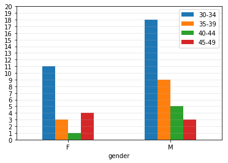

```python
ax = to_graph_df.plot.bar(yticks = range(0, 21,1), rot = 0);
ax.grid(True, axis = 'y', alpha = .3);
ax.legend();
```

```python
temp_df.unstack?
```

## Figure Before and After

```python
# Before
temp_df
```

[output not shown]

```python
# After, bar graph.
temp_df.unstack?
```

```python
temp_df.reset_index(level = 'age')
```

[output not shown]

```python
temp_df.pivot(index = 'age')
```

[output not shown]

```python
!cat ~/anaconda3/lib/python3.6/site-packages/pandas/core/frame.py
```

[output not shown]

[output cut: 6440 more lines]

[output not shown]

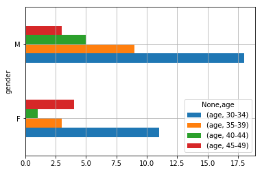

```python
temp_df.unstack().plot.barh()
```

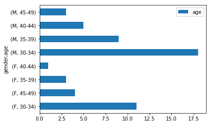

```python
temp_df.plot.barh(sharex = True, sharey = True)
```

```python
import inspect
temp_df.plot.barh

!cat ~/anaconda3/lib/python3.6/site-packages/pandas/plotting/_core.py
```

[output not shown]

[output cut: 2831 more lines]

[output not shown]

```python
fig, ax = plt.subplots(figsize = (15, 10))

a
```

[output not shown]

```python
df_1[df_1.gender == 'M'].age.value_counts()
```

```
30-34    18
35-39     9
40-44     5
45-49     3
Name: age, dtype: int64
```

```python
df_1[df_1.gender == 'F'].age.value_counts()
```

```
30-34    11
45-49     4
35-39     3
40-44     1
Name: age, dtype: int64
```

## Click-through-Rate (CTR)

useful even though wiki: https://en.wikipedia.org/wiki/Click-through_rate

**Click-through rate (CTR)** is the ratio of users who click on a specific link to the number of total users who view a page, email, or advertisement. It is commonly used to measure the success of an online advertising campaign for a particular website as well as the effectiveness of email campaigns. The purpose of click-through rates is to measure the ratio of clicks to impressions of an online ad or email marketing campaign. Generally the higher the CTR the more effective the marketing campaign has been at bringing people to a website

```python
uniqueCampaigns = df.xyz_campaign_id.unique()
```

```python
df_1 = df[df.xyz_campaign_id == uniqueCampaigns[0] ]
df_2 = df[df.xyz_campaign_id == uniqueCampaigns[1] ]
df_3 = df[df.xyz_campaign_id == uniqueCampaigns[2] ]
```

```python
print(df_1['Clicks'].sum() / (df_1['Impressions'].sum() * 1.0) )
print(df_2['Clicks'].sum() / (df_2['Impressions'].sum() * 1.0) )
print(df_3['Clicks'].sum() / (df_3['Impressions'].sum() * 1.0) )
```

```
0.00023399078531863125
0.00024408887246319506
0.00017609288955581687
```

1.) **Click-through-rate (CTR)**. This is the percentage of how many of our impressions became clicks. A high CTR is often seen as a sign of good creative being presented to a relevant audience. A low click through rate is suggestive of less-than-engaging adverts (design and / or messaging) and / or presentation of adverts to an inappropriate audience. What is seen as a good CTR will depend on the type of advert (website banner, Google Shopping ad, search network test ad etc.) and can vary across sectors, but 2% would be a reasonable benchmark.

2.) **Conversion Rate (CR).** This is the percentage of clicks that result in a 'conversion'. What a conversion is will be determined by the objectives of the campaign. It could be a sale, someone completing a contact form on a landing page, downloading an e-book, watching a video, or simply spending more than a particular amount of time or viewing over a target number of pages on a website.

3.) **Cost Per Click (CPC).** Self-explanatory this one: how much (on average) did each click cost. While it can often be seen as desirable to reduce the cost per click, the CPC needs to be considered along with other variables. For example, a campaign with an average CPC of £0.5 and a CR of 5% is likely achieving more with its budget than one with a CPC of £0.2 and a CR of 1% (assuming the conversion value is the same.

4.) **Cost Per Conversion.** Another simple metric, this figure is often more relevant than the CPC, as it combines the CPC and CR metrics, giving us an easy way to quickly get a feel for campaign effectiveness.

There are other values that are also very useful in assessing the performance of a marketing campaign. One of these is the **conversion value**: how much each conversion is worth. For example, our conversion could be a signup form on a landing page to receive information about a new car. If we know that, on average, 1% of people end up purchasing a car for £10,000, we can use that figure in calculating what our target cost per conversion should be.

For an e-commerce site, we could implement conversion tracking to tie-up the value of specific transactions to particular campaigns, this would allow us to assign the actual amount of revenue generated by each campaign / ad creative.

Knowing the conversion value would allow us to calculate other KPIs such as the **Return on Advertising Spend (ROAS)**. While advertising campaigns have other benefits (such as increased brand awareness and future purchases based on customer lifetime value) that may factor into the over return on investment (ROI), ROAS can quickly tell us how a campaign is paying for itself. It is simply the revenue as a percentage of the advertising spend. If a campaign costs £100 and leads to £400 sales, the ROAS is 400% (or 4).

```python
## convert to Python Code.
#dataTf <- dataTf %>%
#  mutate(CTR = ((Clicks / impr) * 100), CPC = Spent / Clicks)

# This is click through rate and cost per click.
```

### The importance of understanding the client

Of course, using ROAS requires an understanding of the client's business. For some clients, a ROAS of 400% might be a great number, for others, they might not be covering their costs. This is why it is important to understand the margins of products being sold through these campaigns.

If an advertiser is selling a product for £120 (£100 in the UK after taking off the sales tax) that costs them £40, they are making £60 gross profit and a margin of 60%. If their ROAS is 400% (if calculated using the inc. tax figure), the advertising costs associated with that sale are £30, so there is a net profit of £30.

If, on the other hand, the product cost £80 (20% margin), the gross profit is only £20, therefore there is a net loss of £10 (before other business overheads are considered).

These simple examples show why it is important to understand, not only the strategic objectives of the marketing activities, but also how specific campaigns support these objectives and how their effectiveness is to be measured and, in the case of retail, what type of margins the client is working with across its product mix.

## Conclusion

Hopefully this notebook has been of some use to if you're new to pay-per-click advertising, or if you've been looking for new ways to try and improve ROI from your digital campaigns.

This notebook is just a quick glimpse into the sort of analyses you can do with your digital advertising datasets, but it really is only a starting point: the correct types of analysis and measures of success will be driven by your own business model and your underlying marketing objectives.

## Google Analytics

As briefly discussed above, while ROAS reports on campaigns tactically, ROI is more strategic. To start to work out ROI, we would likely want to start working with data from other sources, such as our website analytics data. As our Facebook ad campaigns can contain plenty information in the URL that sends visitors to our website, we can look at how much website traffic the campaigns generated and how visitors from that campaign interacted with our website.

With that information, we could look to see if there are other events that we could consider a conversion. Did the visitor subscribe to our email newsletter? Did they spend more than three minutes on the site and browse more than ten pages? Did they bookmark the site and return to make a purchase some time later? If that is the case, their conversion may not be assigned to that campaign in one location, but may be visible as an 'assisted conversion' in the Multi-Channel Funnels section of Google Analytics. Then there are other potential values, such as the ability to now 'remarket/retarget' adverts to that visitor.

### Know where your visitors go, how they interact with you and what goals are worth

Additionally, ROI calculations can consider things such as the lifetime value of the customer. With an advertising campaign, you might not get a sale today, but you might get a visit. Will they come back and purchase later? If a customer makes one purchase, do they end up making more over the next few weeks, months, years...? How much do they spend and does that fall off over time? All of these factors can add up to make that initial cost-per-click better value than it might have seemed at the time.

By assigning values to the various goals you have in place on your website, and by knowing where visitors came from and how they interact with you over time, you can make better judgments and decisions on how your marketing campaigns are performing.

With a clear set of objectives, and a good understanding of the business model, you can really delve into the data with specific questions in mind, allowing you to get the answers you need to make appropriate decisions